[figure not shown]

# Egregious plot tricks

‌

## Different y-axes

**US military spending—Original**

[figure not shown]

Some might use such a figure to push a particular agenda. “Clearly China is a massive threat to global security!”

(Image source: [Federal Reserve Bank of St Louis](https://www.stlouisfed.org/on-the-economy/2023/jan/military-expenditures-how-top-spending-nations-compare) [last accessed: 2023-02-13])

**US military spending—Revised**

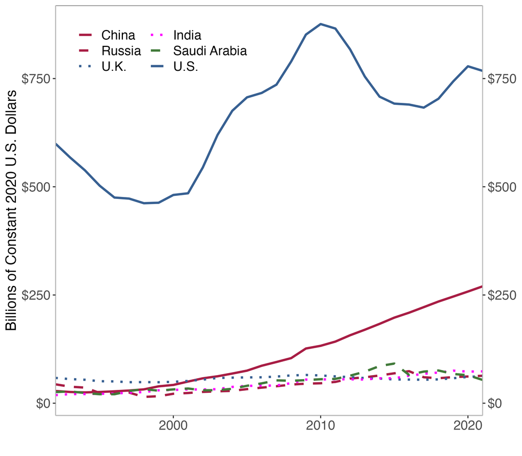

…While China might say they are just following the example of another huge military power? Here expenditure for all countries is plotted on the same scale.

(Image created by CC using data from the [SIPRI Military Expenditure Database](https://www.sipri.org/databases/milex.)

**Discussion**

The first image was produced by the Federal Reserve Bank of St Louis, and there are several issues with it.

The second plot presents the same data in a much more honest way. By measuring all countries’ expenditure on the same, zeroed, axis we see that, China has indeed dramatically increased its military spending, but that they fall significantly short of that of the U.S.

## Missing zeros

**Nationality heights—Original**

[figure not shown]

Also an example of inappropriate use of icons - we are forced to compare the **areas** of the figures, so Indonesians appear tiny and the Dutch appear giant.

(Image source: [Patient.info](https://patient.info/news-and-features/whats-the-average-height-for-men) [Accessed: 2023-01-23])

**Nationality heights—Revised**

[figure not shown]

The website later featured a revised visualization.

(Image source: [Patient.info](https://patient.info/news-and-features/whats-the-average-height-for-men) [Accessed: 2023-02-13])

**Nationality heights—Minimal**

[figure not shown]

Here, we lose the silhouettes, which might be considered by some as “chart junk”. And focus on only the heights. We also add in national flags - which might also be considered chart junk. Depends on how you want to communicate, and to whom.

**Discussion**

Who really thought the first plot was really a good way to compare the heights of people?

There are two main problems.

1. The y-axis does not start at 0
2. The use of human shaped images that are scaled in proportion to the non-zeroed scale mean we compare not only the height of the figures, but also their *areas*.
3. The second plot appeared on the same site some time after the original - maybe someone had a word with someone?
4. The third plot suggests a more minimal way of showing the same data focusing only on height
   - one possible disadvantage is that we lose the sense of how actual people from each country might appear when stood together.

## Symbol choice

**Truncated axis**

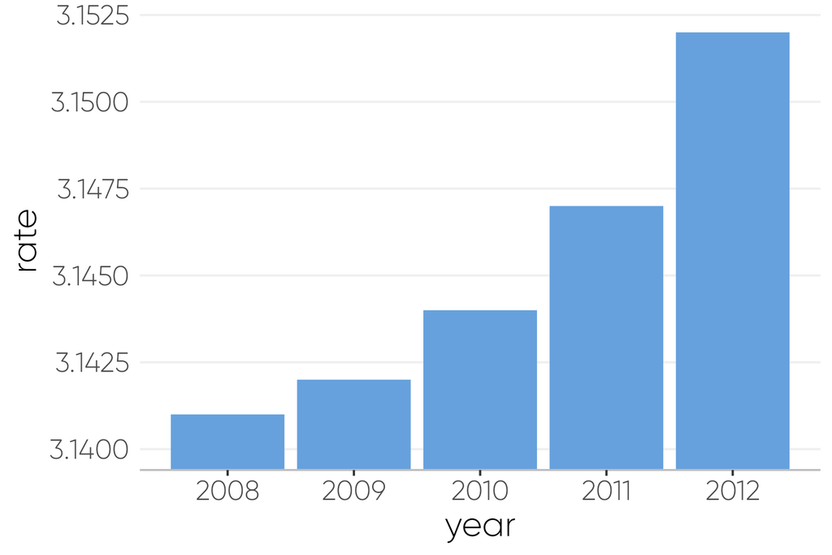

Consider a debate in the House of Commons. The leader of the opposition uses this plot to claim,

> “Under this government, interest rates have sky-rocketed!”

**Expanded axis**

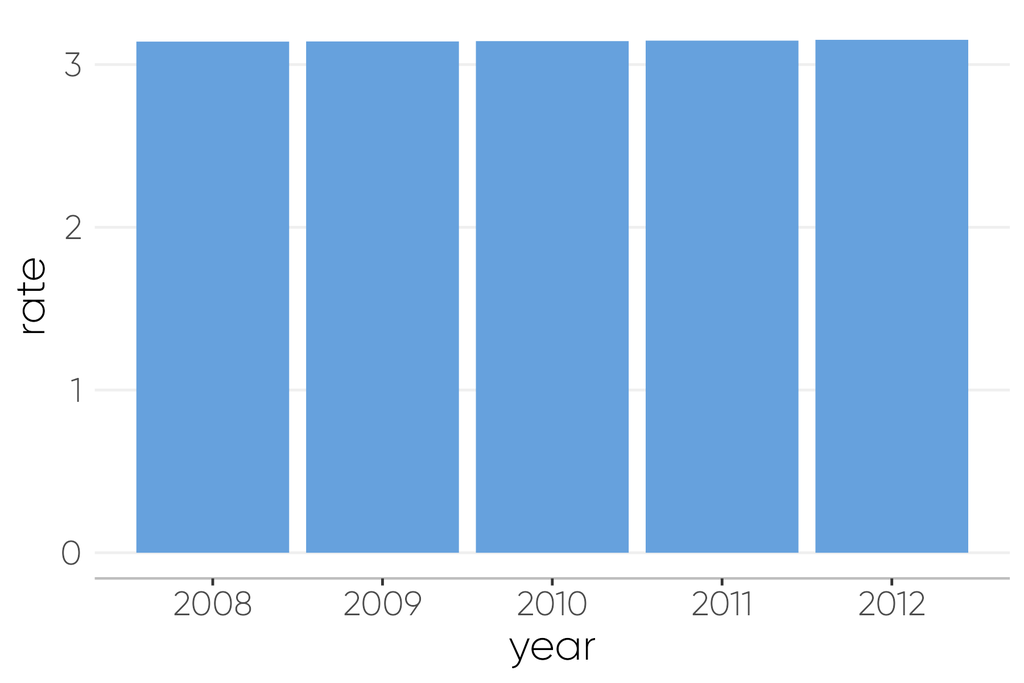

In the same Commons debate, the government presents this figure and says,

> Nonsense! Under our leadership interest rates have remained remakably stable!

**Change symbol?**

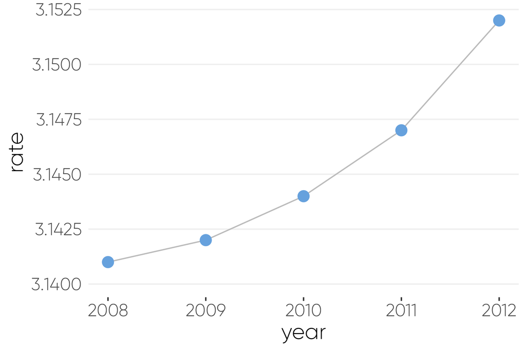

Here, the same data are presented, again with a truncated axis, but this time with points instead of bars.

**Discussion**

In cases where small fractions might actually make a real difference, it may be necessary, and correct, to truncate the axis. In those cases, the real problem might be the choice of plot type. When a bar chart is used we naturally tend to compare the entire area occupied by each of the bars, often without considering the scale on the y-axis. This can unfairly magnify those small differences. By reducing the footprint of each symbol, such that they are all the same, we remove those visual cues. In the final plot, we can no longer judge how important the differences are without explicitly referring to the y-axis.

So, to summarize,

1. The **truncated** axis is a problem
   - because we compare areas of the bars.
2. The **non-truncated** axis is a problem
   - because the differences now totally disappear.
3. The final plot retains the, often abused, truncated axis
   - but we are no longer comparing symbol area.
   - In reality the changes here are pretty minuscule. Only this final plot allows us to appreciate both that fact, and also notice that the real story might be about the **rate** of increase.

## Which graph should you use?

There are four main purposes for creating a graph (Figure 1). These are the standard choices, so if you make an unorthodox choice, you may increase the effort required by your audience to receive the correct message.

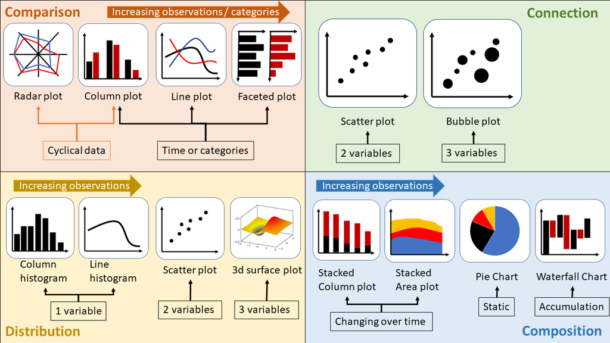

Figure 1: Graphs can be used for comparison, or to show connections, distributions or composotion

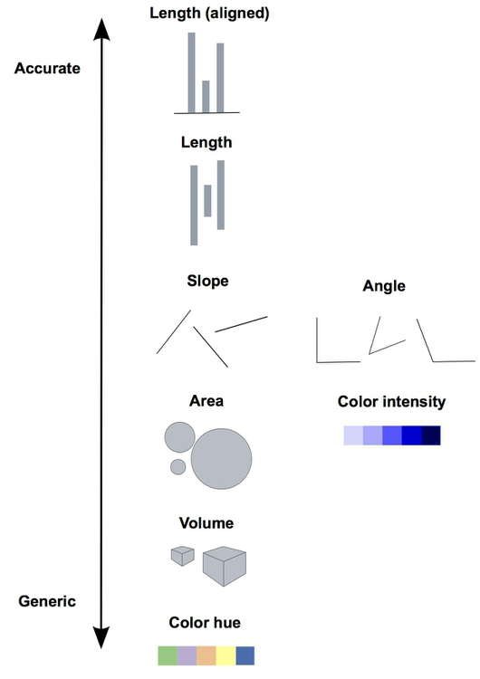

Figure 2: Preattentive attributes in order of discernment

However, just because a type of graph **can** be used, doesn’t mean it is the best choice. are generally more capable of spotting changes or relationship in some attributes than in others (Figure 2). This provides good reasons for choosing / avoiding certain chart types. For example, pie charts are often not recommended because people are less able to compare similar angles. Similarly, funnel plots use unaligned bars. While this appears to be a comparison that people manage well enough, it still makes comparison harder than just a plain bar chart. Finally mapping values to area is often a mistake, and mapping to colour intensity requires careful consideration.

[figure not shown]